# A Shot at the Future: Tracking Polio Vaccination and Its Global Impact - One Dose, One Child, One Life at a Time.

Author

Affiliation

Siddhi Bhute (45804)

Dublin City University

# Introduction

Polio, once one of the world’s most feared diseases, is now closer than ever to being eradicated, but the journey isn’t over yet. Vaccination remains our most powerful tool to protect children and communities, ensuring that no life is left vulnerable to this preventable illness.

In this project, we explore real-world data sourced from UNICEF to examine how countries and regions around the world are performing in their efforts to immunize against polio. By analyzing trends, comparing regions, and investigating the relationship between life expectancy and vaccination rates, we aim to highlight where significant progress has been made and where greater efforts are still needed.

Using Python libraries such as pandas, seaborn, and matplotlib, we extract insights and create clear visualizations that tell the story behind the numbers. Through scatterplots, bar charts, maps, and tables, we uncover important patterns in global vaccination efforts from the top-performing countries to regions that continue to face challenges.

Beyond statistics and visualizations, this report provides an analytical overview of global polio vaccination efforts, highlighting performance variations across regions and examining the relationship between immunization rates and broader health indicators.

```python
#Import required packages
import os
import pandas as pd
import numpy as np
import polars as pl
import matplotlib.pyplot as plt
import matplotlib.colors as mcolors
import colorsys
from matplotlib import colors
import seaborn as sns
from plotnine import *
import geopandas as gpd
import ipywidgets as widgets
from scipy.stats import linregress
from IPython.display import display
from posixpath import join
from datetime import datetime
from google.colab import drive

print("Libraries successfully imported")
```

```
Libraries successfully imported
```

# Dataset

We have used 3 datasets collected from UNICEF which contains polio 3<sup>rd</sup> dose vaccination indicator for children between 12 to 23 months old, a metadata file that contains information about countries such as, population, GDP, GNI, average life expectancy, etc., and UNICEF country-region information file that shows which country belongs to which region.

The datasets were uploaded to Google Drive and used for data analytics and visualization purpose.

```python
#connecting to google drive to read input files
drive.mount('/content/drive')

os.chdir("/content/drive/My Drive/BAA1030")

print("Connected to Google Drive")
```

```
Connected to Google Drive
```

```python
#Load the data into dataframes
country_region_df = pd.read_csv('unicef_country_region_lookup.csv')
indicator_df = pd.read_csv('unicef_indicator_2.csv')
metadata_df = pd.read_csv('unicef_metadata.csv')

print("Dataframes successfully loaded")
```

```
Dataframes successfully loaded
```

# Exploratory Data Analysis (EDA)

EDA is the first step in any data project where we explore, clean, and understand the data to uncover important insights, identify anomalies, and set the foundation for further analysis or machine learning. We performed the following key operations to clean and prepare the datasets:

### Step 1: Dropping Unnecessary Columns

Removed irrelevant columns from both ‘indicator’ and ‘metadata’ datasets to retain only the fields necessary for analysis.  
This streamlines the datasets and avoids unnecessary noise during further processing.

### Step 2: Converting Columns to Appropriate Data Types

Standardized data types across important columns: - Converted year fields (‘time_period’, ‘year’) to string format after parsing as dates. - Converted identifiers like ‘country’, ‘alpha_3_code’, and ‘indicator’ to string types. - Converted ‘numeric_code’ into integer type.

This ensures consistency and prevents type-related issues in future steps.

### Step 3: Removing Data Before 1980

Filtered out entries before 1980 from ‘metadata’ dataset to align with ‘indicator’ dataset, which contains data starting from 1980 onwards.

### Step 4: Removing Blank or Null Values

Dropped any rows containing missing or blank values in both datasets.  
This ensures that further analysis is performed on complete and reliable data.

After completing these EDA steps, the datasets are now cleaner, more consistent, and ready for visualization.

```python
#EDA step1: dropping unnecessary columns

indicator_df = indicator_df.drop(columns=['time_period_activity_related_to_when_the_data_are_collected',
                                          'unit_of_measure', 'unit_multiplier', 'observation_status',
                                          'alpha_2_code', 'observation_confidentaility'])

metadata_df = metadata_df.drop(columns=['inflation_consumer_prices_annual_percentage',
                                          'military_expenditure_percentage_of_gdp',
                                          'fossil_fuel_energy_consumption_percentage_of_total',
                                          'alpha_2_code'])

print("Columns that are not required successfully dropped")

#EDA step2: Convert the columns into appropriate datatypes

indicator_df['time_period'] = pd.to_datetime(indicator_df['time_period'], format='%Y').dt.strftime('%Y')
indicator_df['country'] = indicator_df['country'].astype(str)
indicator_df['numeric_code'] = indicator_df['numeric_code'].astype(int)
indicator_df['alpha_3_code'] = indicator_df['alpha_3_code'].astype(str)
indicator_df['indicator'] = indicator_df['indicator'].astype(str)
indicator_df['sex'] = indicator_df['sex'].astype(str)
indicator_df['current_age'] = indicator_df['current_age'].astype(str)

metadata_df['year'] = pd.to_datetime(metadata_df['year'], format='%Y').dt.strftime('%Y')
metadata_df['country'] = metadata_df['country'].astype(str)
metadata_df['alpha_3_code'] = metadata_df['alpha_3_code'].astype(str)

country_region_df['alpha_3_code']= country_region_df['alpha_3_code'].astype(str)
country_region_df['country'] = country_region_df['country'].astype(str)
country_region_df['region'] = country_region_df['region'].astype(str)

print("Columns successfully converted to appropriate datatypes")

# EDA step3: Remove the data before 1980 from metadata as we have data from 1980 onwards in the indicator file
metadata_df = metadata_df.loc[metadata_df['year'] >= '1980']

print("Data before 1980 successfully removed from metadata")

#EDA step4: Filter out rows with any blank or null values
indicator_df = indicator_df.dropna()
metadata_df = metadata_df.dropna()

print("Rows with any blank or null values successfully removed")
```

```
Columns that are not required successfully dropped
Columns successfully converted to appropriate datatypes
Data before 1980 successfully removed from metadata
Rows with any blank or null values successfully removed
```

```python
#Join all 3 dataframes to create a single one for our vizualization

merged_df = pd.merge(indicator_df, metadata_df, left_on=['alpha_3_code', 'time_period'], right_on=['alpha_3_code', 'year'], how='inner')

joined_df = pd.merge(merged_df, country_region_df, left_on=['alpha_3_code','country_x'], right_on=['alpha_3_code','country'], how='inner')
```

# Visualization #1: World Map

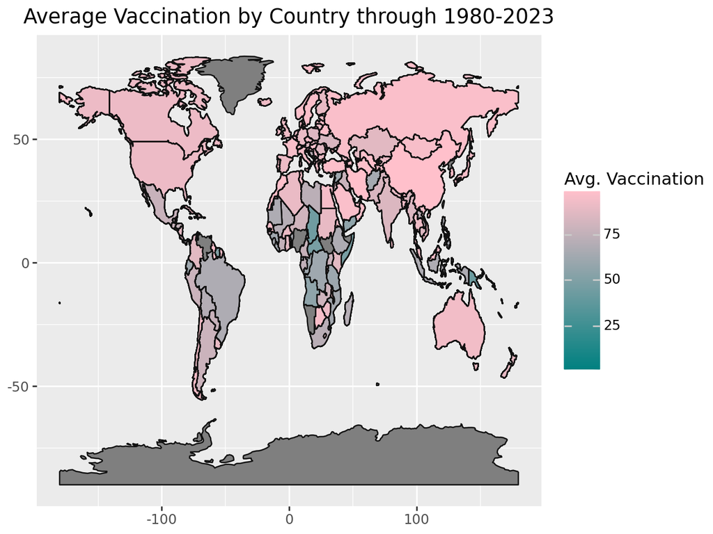

```python
#Loading worldmap data downloaded earlier
world = gpd.read_file("ne_110m_admin_0_countries.shp")

world = world.merge(joined_df, left_on='ADM0_A3', right_on='alpha_3_code', how='left')


#creating world map
(
    ggplot(world, aes(fill='obs_value', geometry='geometry'))
    + geom_map()
    + scale_fill_gradient(low="teal", high="pink")
    + labs(fill="Avg. Vaccination")
    + ggtitle("Average Vaccination by Country through 1980-2023")
)
```

The global map paints a vivid picture of humanity’s long struggle and success in expanding vaccination coverage. Over four decades, the world transitioned from vulnerability to resilience, with many countries now shaded in soft pinks, symbolizing high average vaccination rates above 75%. Yet, the map also reveals stubborn inequalities: Central Africa, parts of the Middle East, and sections of South America remain behind, indicated by darker shades. This visualization reminds us that while vaccines have saved millions of lives globally, political instability, economic disparity, and misinformation continue to create pockets of risk. It’s a call to action as the progress has been extraordinary, but true success will be when all the countries are covered and each child is vaccinated.

# Visualization #2: Time-series Line Chart

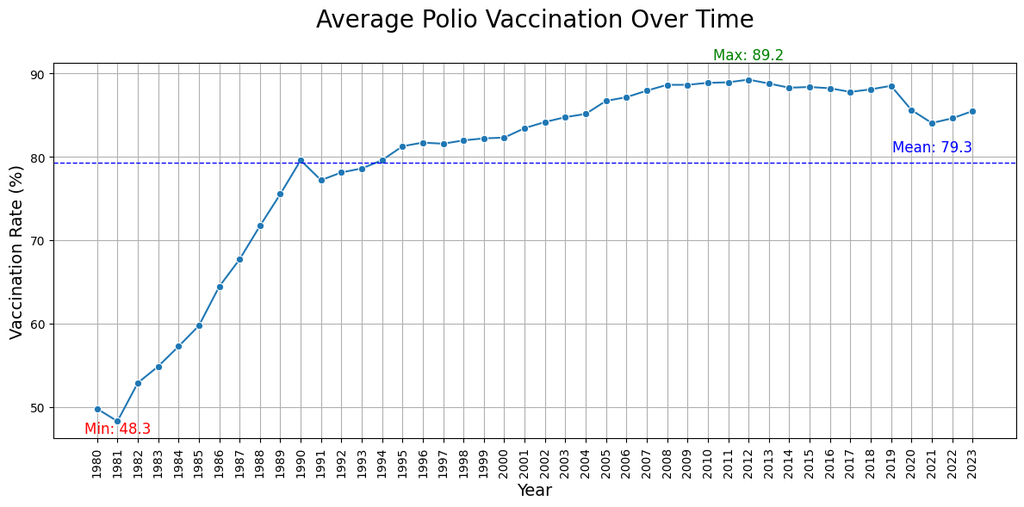

```python
# Creating time-series chart

time_series_df = (
    indicator_df.groupby("time_period", as_index=False)["obs_value"].mean()
)

# Calculate min, max, and mean of average obs_value
min_row = time_series_df.loc[time_series_df["obs_value"].idxmin()]
max_row = time_series_df.loc[time_series_df["obs_value"].idxmax()]
mean_value = time_series_df["obs_value"].mean()

plt.figure(figsize=(12, 6))
ax = sns.lineplot(data=time_series_df, x="time_period", y="obs_value", marker="o")
plt.title("Average Polio Vaccination Over Time", fontsize=20, pad=30)
plt.xlabel("Year", fontsize=14)
plt.ylabel("Vaccination Rate (%)", fontsize=14)
plt.xticks(rotation=90)
plt.grid(True)

#Adding annotations for min, max, and mean obs_value in the visualization
ax.text(
    min_row["time_period"], min_row["obs_value"],
    f"Min: {min_row['obs_value']:.1f}",
    ha="center", va="top", color="red", fontsize=12
)

ax.text(
    max_row["time_period"], max_row["obs_value"] + 2,
    f"Max: {max_row['obs_value']:.1f}",
    ha="center", va="bottom", color="green", fontsize=12
)

plt.axhline(mean_value, color="blue", linestyle="--", linewidth=1)
ax.text(
    time_series_df["time_period"].iloc[-1], mean_value + 1,
    f"Mean: {mean_value:.1f}",
    ha="right", va="bottom", color="blue", fontsize=12
)

plt.tight_layout()
plt.show()
```

# Visualization #3: Bar Graph

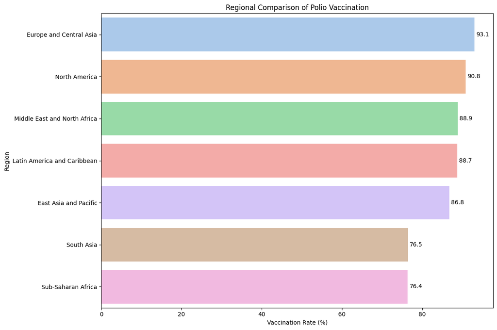

```python
# Creating horizontal bar chart

regional_avg = joined_df.groupby("region", as_index=False)["obs_value"].mean()

regional_avg = regional_avg.sort_values(by="obs_value", ascending=False)

plt.figure(figsize=(12, 8))
ax = sns.barplot(
    data=regional_avg,
    y="region",
    x="obs_value",
    hue="region",
    dodge=False,
    palette="pastel",
    legend=False
)

plt.title("Regional Comparison of Polio Vaccination")
plt.xlabel("Vaccination Rate (%)")
plt.ylabel("Region")

for container in ax.containers:
    ax.bar_label(container, fmt='%.1f', label_type='edge', padding=3)

plt.tight_layout()
plt.show()
```

The bar chart shows average polio vaccination coverage across different UNICEF regions. Europe and Central Asia boast a 93.1% immunization rate, a testament to strong healthcare systems, consistent funding, and public trust in vaccines. In contrast, South Asia (76.5%) and Sub-Saharan Africa (76.4%) expose critical vulnerabilities where millions of children remain at risk of preventable disease. This visualization is powerful because it doesn’t just show averages it shows us global health inequalities that require urgent attention. Vaccination should not be a privilege of geography; it must be a universal right.

# Visualization #4: Table

```python
# Identifying top 10 countries per region based on average obs_value

avg_obs_by_country = joined_df.groupby('country')['obs_value'].mean().reset_index()
avg_obs_by_country = avg_obs_by_country.sort_values('obs_value', ascending=False)

# Function to get top 10 countries per region
def get_top_10_per_region(df, region_col='region', country_col='country', value_col='obs_value'):
    top_10_countries = []
    for region in df[region_col].unique():

        region_df = df[df[region_col] == region]
        region_avg = region_df.groupby(country_col)[value_col].mean().reset_index()
        region_avg_sorted = region_avg.sort_values(by=value_col, ascending=False)
        top_10_countries.extend(region_avg_sorted.head(10)[country_col].tolist())

    return top_10_countries

# Use the function created above to get top 10 countries per region
top_countries = get_top_10_per_region(joined_df)

# Filter the joined_df to fetch top 10 country data
top_10_df = joined_df[joined_df['country'].isin(top_countries)]

# Calculate the average of obs_value and life_expectancy to use in creating the scatterplot
top_10_avg_df = top_10_df.groupby(['region', 'country']).agg({
    'obs_value': 'mean',
    'life_expectancy_at_birth_total_years': 'mean',
    'population_total': 'mean'
}).reset_index()
```

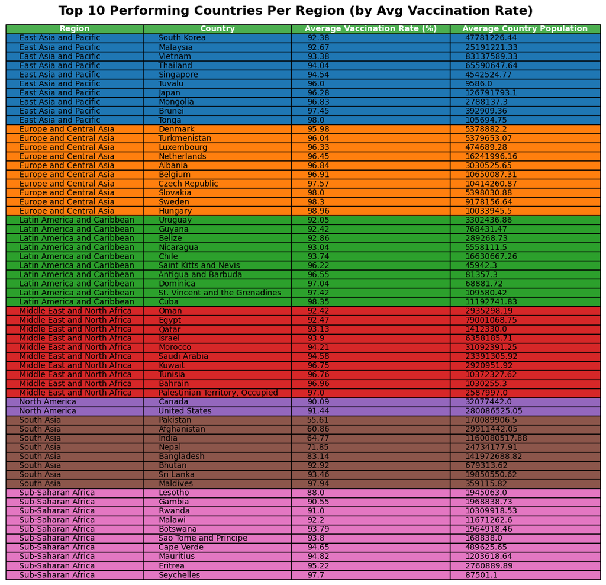

```python
#Creating Table to show top-10 countries per region
top_10_avg_df_sorted = top_10_avg_df.copy()

# Rounding the avg obs_value and population_total to 2 decimal places
top_10_avg_df_sorted['obs_value'] = top_10_avg_df_sorted['obs_value'].round(2)
top_10_avg_df_sorted['population_total'] = top_10_avg_df_sorted['population_total'].round(2)

top_10_avg_df_sorted = top_10_avg_df_sorted.sort_values(['region', 'obs_value'])

fig, ax = plt.subplots(figsize=(10, 6))
ax.axis('off')

table_data = top_10_avg_df_sorted[['region', 'country', 'obs_value','population_total']]
column_titles = ["Region", "Country", "Average Vaccination Rate (%)","Average Country Population"]

# Generate the table
table = ax.table(
    cellText=table_data.values,
    colLabels=column_titles,
    cellLoc='left',
    loc='center'
)

table.auto_set_font_size(False)
table.set_fontsize(10)
table.auto_set_column_width(col=list(range(len(column_titles))))
tab10_colors = sns.color_palette("tab10")
unique_regions = top_10_avg_df_sorted['region'].unique()
region_colors = {region: tab10_colors[i % len(tab10_colors)] for i, region in enumerate(unique_regions)}

for (row, col), cell in table.get_celld().items():
    if row == 0:
        cell.set_text_props(weight='bold', color='white')
        cell.set_facecolor('#4CAF50')
    else:
        region = table_data.iloc[row-1]['region']
        cell.set_facecolor(region_colors.get(region, '#ffffff'))

fig.text(
    0.5, 1.35,
    "Top 10 Performing Countries Per Region (by Avg Vaccination Rate)",
    ha='center',
    va='top',
    fontsize=16,
    fontweight='bold'
)

plt.subplots_adjust(top=0.85)
plt.show()
```

From the table, we can observe: that Countries like Tonga, Cuba, and Sweden consistently achieved very high vaccination rates and developed regions (e.g., Europe, East Asia) generally show higher vaccination rates compared to others.

Some countries in South Asia and Sub-Saharan Africa show lower vaccination rates, highlighting regional gaps.

This visualization helps us quickly spot which countries maintained higher immunization coverage and gives an idea of their population scale over time.

# Visualization #5: Scatterplot

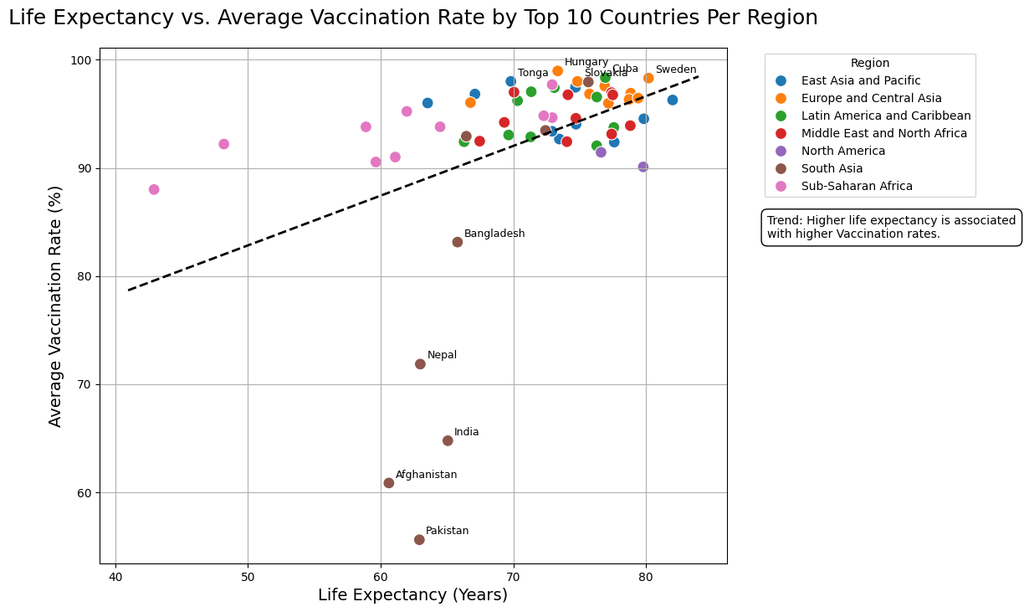

```python
# Creating Scatter plot

# Calculate trend line
slope, intercept, r_value, p_value, std_err = linregress(
    top_10_avg_df["life_expectancy_at_birth_total_years"],
    top_10_avg_df["obs_value"]
)

fig, ax = plt.subplots(figsize=(12, 8))
sns.scatterplot(
    data=top_10_avg_df,
    x="life_expectancy_at_birth_total_years",
    y="obs_value",
    hue="region",
    palette="tab10",
    s=100,
    ax=ax
)

# Adding trend line calculated earlier
x_vals = np.array(ax.get_xlim())
y_vals = intercept + slope * x_vals
ax.plot(x_vals, y_vals, '--', color='black', linewidth=2)

ax.set_title("Life Expectancy vs. Average Vaccination Rate by Top 10 Countries Per Region", fontsize=18, pad=20)
ax.set_xlabel("Life Expectancy (Years)", fontsize=14)
ax.set_ylabel("Average Vaccination Rate (%)", fontsize=14)
ax.grid(True)
legend = ax.legend(title="Region", bbox_to_anchor=(1.05, 1), loc='upper left')
plt.subplots_adjust(right=0.75)
top_countries = pd.concat([
    top_10_avg_df.nlargest(5, 'obs_value'),
    top_10_avg_df.nsmallest(5, 'obs_value')
])

for i, row in top_countries.iterrows():
    ax.text(
        row["life_expectancy_at_birth_total_years"] + 0.5,
        row["obs_value"] + 0.5,
        row["country"],
        fontsize=9,
        color='black'
    )

if slope > 0:
    message = "Trend: Higher life expectancy is associated\nwith higher Vaccination rates."
else:
    message = "Trend: Higher life expectancy is associated\nwith lower Vaccination rates."

fig.text(
    0.79, 0.63,
    message,
    ha='left',
    va='top',
    fontsize=10,
    bbox=dict(boxstyle="round,pad=0.5", facecolor="white", edgecolor="black")
)

plt.show()
```

# Conclusion

Together, these visualizations reveal a powerful story of progress, persistence, and unfinished business. The world map shows how vaccination has expanded across continents, saving millions of lives but also leaving clear gaps that must not be ignored. Regional comparisons highlight significant variations, where some areas have achieved near-universal coverage while others still struggle. The time series graph proves that through sustained global effort, dramatic improvements are possible, yet it also reminds us that progress can quickly stall without continued commitment. Finally, the scatter plot between life expectancy and immunization underscores a deeper truth: vaccines are not just about preventing illness; they are the building blocks of healthier, longer, and more prosperous societies.

The journey from 1980 to 2023 has been remarkable, but the data calls us to action as the future of global health will be defined not just by how far we have come, but by how determined we are to finish the mission and make a healthier environment to live in.

[figure not shown]